# Toetsopdracht 1: Database Optimization

Module

2.4 Advanced Data Management

Publicatiedatum

mei 2023

Samenvatting

In deze opdracht ga je de performance meten in een relationele database. Je gaat verschillende queries schrijven, de query plans bekijken en verschillende constraints toevoegen aan de database. Daarnaast ga je met behulp van indices, denormalisatie en triggers de database verder optimaliseren.

# Examenregels

- De deadline voor het inleveren van de opdracht is maandag 29 mei 2023 om 23:59.
- De opdracht wordt individueel gemaakt.
- Het is *niet* toegestaan om hulp te krijgen van anderen (mensen of AI), behalve van je docent. Het is ook niet toegestaan om anderen te helpen met de opdracht.
- Je mag online posts, artikelen, tutorials, boeken en video’s gebruiken. Je moet dan wel [bronvermelding toevoegen](https://libguides.murdoch.edu.au/ieee/text) voor alle bronnen en codefragmenten die je in je tekst/code gebruikt.

## Beoordeling

- Als je alle onderdelen van de opdracht volledig en (bijna) helemaal correct hebt uitgevoerd, krijg je een *voldoende* voor deze opdracht (1 punt).
- Als je daarnaast je nog verder hebt verdiept in het onderwerp en zelf extra onderzoek hebt gedaan, dan kun je een *uitstekend* krijgen voor de opdracht (1,5 punt extra). Hierbij kun je denken aan het experimenteren met andere soorten indexen, extra queries onderzoeken die nuttig zijn, testen hoe dingen (anders) werken onder verschillende omstandigheden, et cetera. Er wordt hiervoor dus substantieel eigen initiatief en creativiteit gevraagd.
- Tijdens de eerste les van week 4 wordt je werk gereviewd door een andere student (en review jij iemand anders). Voor het schrijven van een goede review over de uitwerking van een andere student krijg je 1 punt extra. Je kunt alleen meedoen met het reviewen als je zelf de opdracht ook op tijd ingeleverd hebt.

In totaal zijn er bij de eerste toetsopdracht dus maximaal 3,5 punten te verdienen.

# Use case

Stack Exchange is een netwerk van websites waar mensen vragen kunnen stellen en beantwoorden over verschillende onderwerpen. Dit zijn met name technische onderwerpen. Het bekendste voorbeeld is de website [StackOverflow](https://stackoverflow.com/).

Data van alle verschillende Stack Exchange websites is vrij toegankelijk. Stack Exchange maakt gebruik van relationele databases voor de opslag van hun data. Door het grote aantal gebruikers is de omvang van deze databases echter gigantisch. Zo is de StackOverflow database bijvoorbeeld zo’n 60 GB (gezipped).

Bij deze opdracht ga je werken met de [DBA Stack Exchange](https://dba.stackexchange.com/), de website waar je met al je databasevragen terecht kunt. Deze dataset is (na wat voorbewerking) ongeveer 160 MB. Hieronder vind je een databasediagram voor deze database.

Het doel van deze opdracht is om de queries die uitgevoerd worden op de Stack Exchange websites te schrijven en de database structuur te optimaliseren, zodat de verschillende websites een goede performance hebben.

De betekenis van de waardes in de `votes.votetypeid`-kolom is als volgt:

1. AcceptedByOriginator
2. UpMod
3. DownMod
4. Offensive
5. Favorite
6. Close
7. Reopen
8. BountyStart
9. BountyClose
10. Deletion
11. Undeletion
12. Spam
13. InformModerator

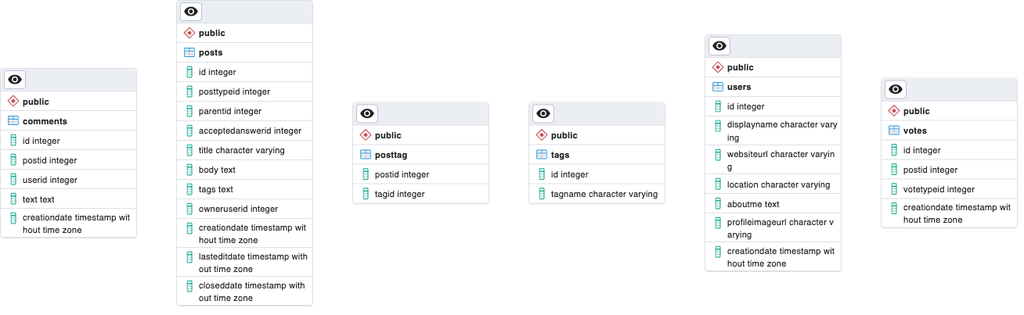

ERD voor DBA StackExchange

## Setup

Om deze opdracht te maken, heb je PostgreSQL nodig (minimaal versie 13) en PgAdmin. Kijk op Blackboard als je dit nog niet geïnstalleerd hebt.

1. Maak een nieuwe database aan in PgAdmin.
2. Klik met de rechtermuisknop op de databasenaam en kies voor *Restore*.
3. Kies als Format ‘Custom or tar’.
4. Open de dump met het knopje bij *Filename*. Het kan zijn dat je hier nog even de keuze moet maken om alle files te laten zien.
5. Klik Restore.

# Opdracht

Schrijf bij volgende onderdelen steeds de gevraagde queries en voer de volgende operaties uit:

1. Bekijk het query plan en leg uit hoe de query wordt geëvalueerd.
2. Noteer hoe lang het duurt op de query uit te voeren.

## Deel 1: Queries schrijven

Voor de verschillende pagina’s van de website gaan we nu de bijbehorende queries schrijven. Onderstaande tabel geeft een overzicht van de pagina’s en de queries die je moet schrijven. Schrijf de queries in het bestand `1_queries.sql`.

[output not shown]

## Deel 2: Primary keys en foreign keys toevoegen

Schrijf SQL om de tabellen aan te passen en primary keys en foreign keys toe te voegen. Schrijf de `ALTER TABLE` statements in het bestand `2_pk_and_fk.sql`.

Voer nu de query `VACUUM ANALYZE` uit, zodat de database engine up-to-date is en bij nieuwe query plannen rekening houdt met je wijzigingen.

Herhaal nu de queries van deel 1, sla de query plans op en beschrijf per query op welke verschillen je ziet.

## Deel 3: Indices

In PostgreSQL wordt er standaard een index aangemaakt voor iedere primary key. Bij foreign keys echter niet. Een index levert snelheidswinst op bij leesoperaties, maar zorgt voor overhead bij insert, update en delete. Normaal gesproken ga je dus zorgvuldig om met het selecteren van je indices.

Bij deze opdracht kijken we enkel naar de leesperformance In dit geval ga je voor iedere foreign key een index aanmaken. Sla de SQL die je schrijft om de indices aan te maken op in `3_indices.sql`.

- Schrijf SQL om voor iedere eerder gedefinieerde foreign key een index aan te maken.
- Voeg daarnaast full-text indices toe aan de title/body velden in de post tabel.

Voer nu de query `VACUUM ANALYZE`, zodat de database engine up to date is en bij nieuwe query plannen rekening houdt met je wijzigingen.

Herhaal nu de queries van deel 1, sla de query plans op en beschrijf per query op welke verschillen je ziet.

## Deel 4: Denormalisatie en triggers

De database die we momenteel gebruiken is genormaliseerd in de derde normaalvorm. Er wordt geen data dubbel opgeslagen. Het zorgt er echter wel voor dat onze queries complex zijn en dat er veel verschillende tabellen gecombineerd moeten worden. Dat kan een enorme impact hebben op de performance van de database. Voornamelijk wanneer een database veel meer gebruikt wordt voor leesoperaties dan voor schrijfoperaties.

Een oplossing hiervoor is denormalisatie. We gaan nu enkele geaggregeerde waarden en waarden die vaak worden opgevraagd *cachen*.

Om de database toch consistent te houden, gaan we gebruik maken van *triggers*. Een trigger is een query die uitgevoerd wordt wanneer een INSERT, UPDATE of DELETE actie wordt uitgevoerd.

##### 4a: Databasestructuur aanpassen

Schrijf `ALTER TABLE` statements om de verschillende tabellen aan te passen.

Je mag zelf kiezen welke velden je gaat denormaliseren, maar zorg dat je in ieder geval de volgende velden meeneemt:

- Vote score van iedere post.
- Aantal antwoorden bij een vraag.
- Aantal comments bij iedere post.

Voer nu de query `VACUUM ANALYZE`, zodat de database engine up to date is en bij nieuwe query plannen rekening houdt met je wijzigingen.

##### 4b: Invoeren van waardes

De kolommen die je net hebt toegevoegd zijn nu nog leeg. Schrijf queries om al deze kolommen te vullen met de juiste waarden. Sla deze queries op in `4b_insert.sql`.

##### 4c: Triggers aanmaken

Maak nu triggers voor de verschillende velden, zodat een INSERT, UPDATE of DELETE ervoor zorgt dat de kolommen automatisch worden bijgewerkt.

##### 4d: Queries herschrijven

Herschrijf nu de queries van Opdracht 1, zodat de gedenormaliseerde waarden worden gebruikt. Sla de query plannen op en vergelijk met de queries van deel 1.

## Wat lever je op?

- De queries, query plannen met uitleg en metingen.
- Schrijf een kort verslagje over wat je aanpak was, welke problemen je tegenkwam, welke onderdelen van jouw oplossing nog verbeterd kunnen worden en welke eigen initiatieven je genomen hebt voor extra onderzoek (maximaal 2 à 3 pagina’s).
- Maak tot slot één groot SQL-script `optimize.sql` waarin je al je queries voor de database-aanpassingen kopieërt. Iemand anders zou met dit script een nieuw ingeladen Stack Exchange database in één keer naar jouw geoptimaliseerde database moeten kunnen omzetten.

# Studiemateriaal

## Artikelen

- [Aggregation functions in PostgreSQL](https://www.postgresql.org/docs/15/functions-aggregate.html)
- [All possible EXPLAIN nodes](https://pganalyze.com/docs/explain)
- [Writing PostgreSQL triggers](https://www.postgresql.org/docs/current/sql-createtrigger.html)
- [Practical example of writing triggers](https://www.postgresqltutorial.com/postgresql-triggers/creating-first-trigger-postgresql/)
- [Nine ways to shoot yourself in the foot with PostgreSQL](https://philbooth.me/blog/nine-ways-to-shoot-yourself-in-the-foot-with-postgresql)